# Iteration

lession 8

Eviatar Guttman

Last updated: 07-07-2021

```r
library(tidyverse)
```

לצמצום כפילות בקוד יש שלוש תועלות עיקריות:  
1. העין ממוקדת במה ששונה בקוד  
2. צורך לשנות רק במקום אחד  
3. פחות באגים

# 1 for loops

דוגמא ל- `for loop` על **ערכים** של וקטור באמצעות האינדקס:

```r
info <- c(name = "eviatar", country = "israel")

for(i in 1:2){
  print(paste("Element", i, "contains", info[[i]]))
}
```

```
## [1] "Element 1 contains eviatar"
## [1] "Element 2 contains israel"
```

דוגמא ל- `for loop` על **השמות** של וקטור:

```r
for (elem in names(info)) {
    print(paste("Element", elem, "contains", info[elem]))
}
```

```
## [1] "Element name contains eviatar"
## [1] "Element country contains israel"
```

דוגמא מעשית, `for loop` על האינדקסים של `df`:

```r
df <- tibble( a = rnorm(10),b = rnorm(10),c = rnorm(10),d = rnorm(10))

# 1. output
output <- vector("double", ncol(df))

# 2. sequence - loop over the indices of the df
for (i in seq_along(df)) {

  # 3. body
  output[[i]] <- median(df[[i]])

  }

output
```

```
## [1]  0.2874579  0.3896322 -0.1310488 -0.2481033
```

מעשית, לכל `for loop` יש שלושה רכיבים:  
1. ה-output:  
`output <- vector("double", length(x))`

אם תגדילו את ה-output בכל איטרציה תוך שימוש ב -`c()`, הלופ יהיה מאד איטי.

2. ה- sequence:  
   `i in seq_along(df)`  
   אם יש לכם ווקטור באורך 0 אז `seq_along` עושה את הדבר הנכון:

```r
y <- vector("double", 0)

seq_along(y)
## integer(0)

1:length(y)
```

```
## [1] 1 0
```

3. ה-body:  
   `output[[i]] <- median(df[[i]])`  
   זה הקוד שעושה את העבודה.  
   באיטראציה הראשונה הקוד שירוץ הוא:  
   `run output[[1]] <- median(df[[1]])`.  
   באיטראציה השניה זה:  
   `output[[2]] <- median(df[[2]])`  
   וכך הלאה.

תבנית של `for loop`:

```r
output <- vector("double", ncol(df))

for (i in seq_len(length(df))){

    output[[i]] <- fun(df[[i]])

    }
```

## 1.1 exercises

1. חשב את הממוצע של כל עמודה ב- `mtcars`.
2. ברר מהו סוג העמודה עבור כל עמודה בטבלה `nycflights13::flights`
3. חשב את מספר הערכים הייחודיים בכל עמודה בטבלה `iris`.
4. זה נפוץ לראות לופ שלא מקצה מקום לתוצאות מלכתחילה, אלא מגדיל את הווקטור בכל איטראציה:

```r
output <- vector("integer", 0)
for (i in seq_along(x)) {
  output <- c(output, lengths(x[[i]]))
}
output
```

כיצד זה משפיע על המהירות? תכנן ובצע ניסוי שבודק זאת.

# 2 for loop variations

## 2.1 Modify existing object

נחזור לפונקציה `rescale` אשר עבדנו איתה במפגש שעסק בפונקציות:

```r
df <- tibble(
  a = rnorm(10, 5),
  b = rnorm(10, 3),
  c = rnorm(10, 2),
  d = rnorm(10, 1))

df
```

```
## # A tibble: 10 x 4
##        a     b     c      d
##    <dbl> <dbl> <dbl>  <dbl>
##  1  3.65  2.94 2.90   2.38
##  2  4.56  3.54 0.450  0.800
##  3  4.71  3.77 0.460  1.96
##  4  5.67  2.48 2.91   0.520
##  5  5.33  1.93 2.76   0.982
##  6  4.84  2.15 1.22   0.528
##  7  3.88  1.30 1.67   1.24
##  8  3.98  4.20 2.84   0.906
##  9  4.39  1.40 0.818  2.29
## 10  4.73  2.47 3.82  -1.04
```

```r
rescale01 <- function(x) {
  rng <- range(x, na.rm = TRUE)
  (x - rng[1]) / (rng[2] - rng[1])
}
```

נחליף את הווקטורים הקיימים בווקטורים חדשים

```r
for (i in seq_along(df)) {
  df[[i]] <- rescale01(df[[i]])
}

df
```

```
## # A tibble: 10 x 4
##        a      b       c     d
##    <dbl>  <dbl>   <dbl> <dbl>
##  1 0     0.566  0.727   1
##  2 0.450 0.771  0       0.538
##  3 0.525 0.852  0.00292 0.875
##  4 1     0.408  0.730   0.456
##  5 0.832 0.218  0.686   0.591
##  6 0.591 0.292  0.229   0.458
##  7 0.113 0      0.362   0.665
##  8 0.164 1      0.711   0.569
##  9 0.367 0.0353 0.109   0.973
## 10 0.533 0.402  1       0
```

האופרטור `[[` מבהיר לקורא שאנו רוצים לעבוד עם רכיב יחיד!

## 2.2 Loop over names

כתיבת לופ מהצורה:  
`(nm in names(xs)` נותנת שם שניתן לגשת אליו עם  
`x[[nm]]`.  
זה מועיל כאשר רוצים להשתמש בשם כדי לשים אותו בכותרת של גרף או שם של קובץ. אם אתם יוצרים תוצר עם שמות וודאו שאתם גם נותנים לווקטור התוצרים שמות באופן הבא:

```r
results <- vector("list", length(x))
names(results) <- names(x)
```

איטראציה על המיקום הנומרי (האינדקס) זו הדרך הכללית ביותר משום שבהינתן מיקום אפשר לחלץ גם את הערך וגם את השם:

```r
for (i in seq_along(x)) {
  name <- names(x)[[i]]
  value <- x[[i]]
}
```

## 2.3 Unknown output length

לעיתים אנו לא יודעים מה אורך התוצר שיהיה.  
למשל, נעשה סימולציה של משיכת ערכים מווקטורים עם אורך רנדומאלי:

```r
means <- c(0, 1, 2, 3, 4, 5)
output <- double()
for (i in seq_along(means)) {
  n <- sample(10, 1)
  output <- c(output, rnorm(n, means[[i]]))
}

str(output)
```

```
##  num [1:35] 0.7712 -0.5114 1.2008 -0.5619 -0.0563 ...
```

פתרון טוב יותר הוא לשמור את התוצרים ב-`list` ולאחר מכן לחבר הכל יחדיו לאחר שהלופ יסתיים.

```r
out <- vector("list", length(means))

for (i in seq_along(means)) {

  n <- sample(100, 1)
  out[[i]] <- rnorm(n, means[[i]])
}

str(out)
```

```
## List of 6
##  $ : num [1:28] -0.043399 0.630124 0.000929 0.411141 0.46728 ...
##  $ : num [1:62] 1.058 0.65 2.421 0.945 2.14 ...
##  $ : num [1:46] 2.7 3.08 3.07 2.4 2.86 ...
##  $ : num [1:94] 3.2 3.59 3.09 1.82 2.44 ...
##  $ : num [1:64] 1.44 3.54 3.8 4.7 4.14 ...
##  $ : num [1:76] 6.93 5.57 5.5 5.74 3.69 ...
```

`unlist` משמש לשטח רשימה של וקטורים לווקטור יחיד. פתרון נוסף הוא באמצעות: `purrr::flaten_dpl`

```r
str(unlist(out))
```

```
##  num [1:370] -0.043399 0.630124 0.000929 0.411141 0.46728 ...
```

1. אם אתם יוצרים `string` ארוך, אז במקום להשתמש ב-`paste` בכל איטראציה בכדי לחבר את תוצאת הביניים עם מה שנצבר עד כה, שמרו את התוצאות בווקטור אחד. לאחר שהלופ יסתיים השתמשו ב –  
   `paste(output, collapse = "")`.
2. אם אתם יוצרים טבלת נתונים `df` גדולה, אז במקום להשתמש ב-`rbind` בכל איטראציה, שמרו את התוצר ב-`list` ולבסוף השתמשו ב- `dplyr::bind_rows(output)` בכדי לחבר את כל התוצרים יחדיו ל-`df` יחיד.

## 2.4 Nested for loop

example:

```r
for (i in 1:2) {
    for (j in 1:3) {
        print(paste("i =", i, "j =", j))
    }
}
```

```
## [1] "i = 1 j = 1"
## [1] "i = 1 j = 2"
## [1] "i = 1 j = 3"
## [1] "i = 2 j = 1"
## [1] "i = 2 j = 2"
## [1] "i = 2 j = 3"
```

Its usefull for matrixes:

```r
(x <- matrix(c(9, 0, 3, 17, 5, 2), ncol = 3))
```

```
##      [,1] [,2] [,3]
## [1,]    9    3    5
## [2,]    0   17    2
```

```r
# Loop
for (i in 1:2) {
    for (j in 1:3) {
        print(paste0("Element x[", i, ", ", j, "] is ", x[i, j]))
    }
}
```

```
## [1] "Element x[1, 1] is 9"
## [1] "Element x[1, 2] is 3"
## [1] "Element x[1, 3] is 5"
## [1] "Element x[2, 1] is 0"
## [1] "Element x[2, 2] is 17"
## [1] "Element x[2, 3] is 2"
```

It is crucial to not mix up the dimensions and/or indices. The following loop …

```r
for (i in 1:3) {
    for (j in 1:2) {
        print(paste0("Element x[", i, ", ", j, "] is ", x[i, j]))
    }
}
```

```
## [1] "Element x[1, 1] is 9"
## [1] "Element x[1, 2] is 3"
## [1] "Element x[2, 1] is 0"
## [1] "Element x[2, 2] is 17"
## Error in x[i, j]: subscript out of bounds
```

by name:

```r
# Create demo matrix
(x <- matrix(c(28, 35, 13, 13, 1.62, 1.53, 1.83, 1.71, 65, 59, 72, 83),
             nrow = 4, dimnames = list(c("Eviatar", "Anat", "Yasmin", "Fatema"),
                                       c("Age", "Size", "Weight"))))
```

```
##         Age Size Weight
## Eviatar  28 1.62     65
## Anat     35 1.53     59
## Yasmin   13 1.83     72
## Fatema   13 1.71     83
```

```r
for (rname in rownames(x)) {
    for (cname in colnames(x)) {
        print(paste("The", cname, "of", rname, "is", x[rname, cname]))
    }
}
```

```
## [1] "The Age of Eviatar is 28"
## [1] "The Size of Eviatar is 1.62"
## [1] "The Weight of Eviatar is 65"
## [1] "The Age of Anat is 35"
## [1] "The Size of Anat is 1.53"
## [1] "The Weight of Anat is 59"
## [1] "The Age of Yasmin is 13"
## [1] "The Size of Yasmin is 1.83"
## [1] "The Weight of Yasmin is 72"
## [1] "The Age of Fatema is 13"
## [1] "The Size of Fatema is 1.71"
## [1] "The Weight of Fatema is 83"
```

loop over columns and compute the mean of each column:

```r
for (var in colnames(x)) {
    m <- mean(x[, var])
    print(paste("Average", var, "is", m))
}
```

```
## [1] "Average Age is 22.25"
## [1] "Average Size is 1.6725"
## [1] "Average Weight is 69.75"
```

## 2.5 Conditional execution

שילוב של תנאי `if` עם `for loop`:

```r
n <- 5L

for (i in 1:(n+1) ){
    if (i <= n) cat(NA, "") else cat("yes!", i ,"is bigger  ")
}
## NA NA NA NA NA yes! 6 is bigger
```

דוגמא קצת יותר מעשית

```r
first_name <- c("Lea",     "Sabine", "Mario", "Lea", "Peter",   "Max")
last_name  <- c("Schmidt", "Gross",  "Super", "Kah", "Steiner", "Muster")

for (i in seq_along(first_name)) {
    # Check if first_name[i] is Lea. If so, print.
    if (first_name[i] == "Lea") {
        print(paste("Found:", first_name[i], last_name[i]))
    }
}
```

```
## [1] "Found: Lea Schmidt"
## [1] "Found: Lea Kah"
```

## 2.6 interim results

אפשר להשתמש בתוצאות בייניים בכדי לבצע חישובים רקורסיביים או כדי לקבל מידע על התהליך.  
דוגמא:

Initialize $x_1 = 1$

Recursively set $x_i = 1.5 x_{i-1}, for$ $i = 2,...N$

```r
N <- 7                         # Max. number of iterations

(x <- vector("numeric", 7))    # Empty vector (fixed length)
```

```
## [1] 0 0 0 0 0 0 0
```

```r
(x[1] <- 1)    # starting value
```

```
## [1] 1
```

```r
# The loop
for (i in 2:N) {
    # Do the calculation. Take 'x' from the previous (i-1)
    # iteration, multiply, store on x[i] (current iteration).
    x[i] <- 1.5 * x[i - 1]
}

print(x)
```

```
## [1]  1.00000  1.50000  2.25000  3.37500  5.06250  7.59375 11.39062
```

ה“טריק” פה הוא שהמיקום היחסי משתנה תוך כדי האיטראציות.

## 2.7 exercises

1. יש לכם תיקייה מלאה בקבצי CSV שאתם רוצים לעלות ל-R. ה-`path` לכל אחד מהקבצים נמצא בווקטור:

`dir("8_data", pattern = "\\.csv$", full.names = TRUE)`

כתבו `for loop` שייבא את הקבצים ויהפוך אותם ל-`df` יחיד.

2. מה קורה אילו השתמשתם ב- `for (nm in names(x))` ול-x אין שמות? מה קורה אילו רק לחלק מהרכיבים ב-x יש שמות? מה קורה אילו ישנם שמות שאינם ייחודיים (מצב בו אותו השם חוזר יותר מפעם אחת)?
3. כתוב פונקציה שמדפיסה את הממוצע של כל עמודה ב-`df` ויחד איתה גם את שם העמודה. למשל, `show_mean(iris)` תדפיס:

`show_mean(iris)`

`# > Sepal.Length: 5.84`  
`# > Sepal.Width: 3.06`  
`# > Petal.Length: 3.76`  
`# > Petal.Width: 1.20`

# 3 `while` loop

לופ `while` טוב לבעיות בהן מספר האיטראציות לא ידוע מראש. זה שימושיים בסימולציות.  
המבנה הכללי הוא:

```r
while (condition) {
  # body
}
```

[output not shown]

היזהרו מלופים אינסופיים. אל תעשו את זה:

```r
# x <- 1
# while (x > 0){
#  x <- x + 1

# }
```

דוגמא:

```r
# Start with 0
x <- 0

# Loop until condition is FALSE
while (x ^ 2 < 20) {

  print(x)      # Print x

  x <- x + 1    # Increase x by 1

}
```

```
## [1] 0
## [1] 1
## [1] 2
## [1] 3
## [1] 4
```

לופ `while` הוא יותר כללי מ-`for loop`. ניתן לכתוב כל `for loop` בצורת `while loop`.

```r
for (i in seq_along(x)) {
  # body
}

# Equivalent to
i <- 1
while (i <= length(x)) {
  # body
  i <- i + 1
}
```

```r
flip <- function() sample(c("T", "H"), 1)

flips <- 0
nheads <- 0

while (nheads < 3) {
  if (flip() == "H") {
    nheads <- nheads + 1
  } else {
    nheads <- 0
  }
  flips <- flips + 1
}
flips
```

```
## [1] 24
```

דוגמא אחרונה: ניתן לחזור על הדוגמא הריקורסיבית תוך שימוש ב-`while`.

```r
x <- c(1)        # The initial value
i <- 1           # Initialize i = 1

# The loop. The while condition is 'x[i] < 10';
# Stops as soon as this condition is no longer TRUE.
while(x[i] < 10) {
    # Calculate new interim result
    # Combine existing vector y with new result
    x <- c(x, 1.5 * x[i])

    # Increase iteration counter after calculation.
    # Could be done before (changes relative index position!).
    i <- i + 1
}
x
```

```
## [1]  1.00000  1.50000  2.25000  3.37500  5.06250  7.59375 11.39062
```

# 4 For loop vs functionals

נניח שברצונו לחשב פונקציה על קבוצת עמודות

```r
df <- tibble(
  a = rnorm(10),
  b = rnorm(10),
  c = rnorm(10),
  d = rnorm(10))

col_mean <- function(df) {

  output <- vector("double", length(df))

  for (i in seq_along(df)) {

    output[i] <- mean(df[[i]])
  }

  output
}

col_mean(df)
```

```
## [1]  0.09760837 -0.19638851  0.17540873  0.16234701
```

כעת אנו רוצים לחשב סטיית תקן עבור כל עמודה. מוטב לעדכן את הפונקציה:

```r
col_fun <- function(df, fun) {

  output <- vector("double", length(df))

  for (i in seq_along(df)) {

    output[i] <- fun(df[[i]])
    }

  output
}


col_fun(df, sd)
```

```
## [1] 0.5823300 1.0166602 0.8852644 1.1281408
```

```r
col_fun(df, min)
```

```
## [1] -1.080890 -1.501189 -1.529511 -2.211083
```

```r
col_fun(df, sum)
```

```
## [1]  0.9760837 -1.9638851  1.7540873  1.6234701
```

דוגמא נוספת:

```r
f1 <- function(x) abs(x - mean(x)) ^ 1
f2 <- function(x) abs(x - mean(x)) ^ 2
f3 <- function(x) abs(x - mean(x)) ^ 3

x <- 1:10

f1(x)
```

```
##  [1] 4.5 3.5 2.5 1.5 0.5 0.5 1.5 2.5 3.5 4.5
```

```r
f2(x)
```

```
##  [1] 20.25 12.25  6.25  2.25  0.25  0.25  2.25  6.25 12.25 20.25
```

מוטב לעדכן את הפונקציה

```r
f <- function(x, i) abs(x - mean(x)) ^ i

f(x, 2)
```

```
##  [1] 20.25 12.25  6.25  2.25  0.25  0.25  2.25  6.25 12.25 20.25
```

**functional** זו פונקציה שב-input היא מקבלת כארגומנט פונקציה אחרת ומחזירה ווקטור ב-output.

“The idea of passing a function to another function is an extremely powerful idea, and it’s one of the behaviors that makes R a functional programming language.”

```r
triple <- function(x) x * 3

map(1:3, triple)
## [[1]]
## [1] 3
##
## [[2]]
## [1] 6
##
## [[3]]
## [1] 9
```

# 5 purrr

נשתמש בחבילה `purrr`.  
האופן שבו `purrr` פועלת זה שהיא פותרת את הבעיה על רכיב יחיד ואז מכלילה את הפתרון לכל רכיב ב-`list`.

The apply family of functions in base R (`apply()`, `lapply()`, `tapply()`, etc) solve a similar problem, but `purrr` is more consistent and thus is easier to learn.

בעוד שב-`dplyr` מבנה הנתונים העיקרי הוא `data frame`, ב-`purrr` עובדים בעיקר עם `list`.

## 5.1 the `map` functions

האובייקט שנכנס לכל פונקציית `map` הוא תמיד אחד מ:

- ווקטור (מכל סוג). במקרה זה האיטראציה נעשית על כל רכיב בווקטור.
- `list`. במקרה זה האיטראציה מבוצעת על רכיבים ב-`list`.
- `data frame`. במקרה בזה האיטראציה מבוצעת על עמודות בטבלה. (למעשה, df זה מקרה מיוחד של list )  
  מכיוון שהארגומט הראשון הוא תמיד ה –data, פונקציות ה-map עובדות יפה עם ה- `pipe %>%`.

נגדיר פונקציה

```r
add10 <- function(.x) {
  return(.x + 10)
}

add10(5)
```

```
## [1] 15
```

נשתמש בה בתוך `map`:

```r
map(.x = c(1,3,5), .f = add10)
## [[1]]
## [1] 11
##
## [[2]]
## [1] 13
##
## [[3]]
## [1] 15
```

ובקיצור:

```r
map(c(1,3,5), add10)
```

`map` תמיד מחזירה `list`.

יש פונקציות עם סיומות שונות לכל סוג של output שרוצים:

`map_lgl()` makes a logical vector.  
`map_int()` makes an integer vector.  
`map_dbl()` makes a double vector.  
`map_chr()` makes a character vector.

`map_df()` makes a data.frame.

כל פונקציה מקבלת ווקטור כ-input, מפעילה את הפונקציה על כל רכיב ואז מחזירה ווקטור באותו אורך.  
היתרון המרכזי בשימוש בפונקציות כמו `map` הוא לא המהירות אלא הבהירות. זה הופך את הקוד ליותר קריא.

```r
map(df, mean)
```

```
## $a
## [1] 0.09760837
##
## $b
## [1] -0.1963885
##
## $c
## [1] 0.1754087
##
## $d
## [1] 0.162347
```

```r
map_dbl(df, mean)
```

```
##           a           b           c           d
##  0.09760837 -0.19638851  0.17540873  0.16234701
```

```r
map_chr(mtcars, typeof)
```

```
##      mpg      cyl     disp       hp     drat       wt     qsec       vs
## "double" "double" "double" "double" "double" "double" "double" "double"
##       am     gear     carb
## "double" "double" "double"
```

תשומת הלב היא על מה שנעשה.

כל פונקציות ה-map מחזירות ווקטור באותו אורך של ה input. משמע, כל קריאה לפונקציה `.f` צריכה להחזיר ערך יחיד. אם לא, יתקבל `error`:

```r
pair <- function(x) c(x, x)

map_dbl(1:2, pair)
```

```
## Error: Result 1 must be a single double, not an integer vector of length 2
```

זה דומה ל-`error` שיתקבל אם `.f` מחזירה ouput מהסוג הלא נכון:

```r
map_dbl(1:2, as.character)
```

```
## Error: Can't coerce element 1 from a character to a double
```

```r
map_chr(1:2, as.character)
```

```
## [1] "1" "2"
```

זה מועיל בד"כ לחזור ל-`map` הבסיסי כי הוא יכול לקבל כל סוג של output

```r
map(1:2, pair)
## [[1]]
## [1] 1 1
##
## [[2]]
## [1] 2 2
```

ההבדלים בין `map` לפונקציה `col_fun` שיצרנו הם:  
1. כל הפונקציות ב-purrr מיושמות בשפת C. זה הופך אותן מעט יותר מהירות על חשבון readability.  
2. הארגומנט השני `.f` , הפונקציה שרוצים להפעיל, יכול להיות נוסחה ( ווקטור character )  
3. `map_*` משתמשת ב- `…` בכדי להעביר ארגומנטים נוספים ל- `.f` בכל פעם שקוראים ל- `.f`.

```r
map_dbl(df, mean, trim = 0.5)
```

```
##          a          b          c          d
##  0.2426337 -0.4262934  0.1963053  0.4146318
```

4. פונקציות ה-map שומרות על שמות:

```r
z <- list(x = 1:3, y = 4:5)

map_int(z, length)
## x y
## 3 2
```

## 5.2 shortcuts

כדי לעשות את הקוד יותר קצר, ניתן להשתמש ב `~.` (טילדה ונקודה) כדי לכתוב בקיצור פונקציה אנונימית (פונקציה ללא שם) בתור הפונקציה שאנו יוצרים כדי להזין כארגומנט.  
אנו מחליפים הביטוי הבא:

```r
function(x) {
  x + 10
}
```

עם הביטוי:

```r
~{.x + 10}
```

הטילדה ~ , מסמלת שמתחילה פונקציה אנונימית. לארגומנט של הפונקציה האנונימית ניתן לקרוא `.x` או בקיצור `.` (נקודה בלבד).  
שלא כמו פונקציות רגילות בהן ניתן לבחור את שם הארגומנט כרצוננו, הסימונים האלה קבועים. הארגומנט של פונקציית ה `tilde-dot` הוא תמיד `.x`.  
כלומר, במקום להגדיר את הפונקציה `add10` בנפרד, אפשר להשתמש בקיצור:

```r
map_dbl(c(1, 4, 7), ~{.x + 10})
```

```
## [1] 11 14 17
```

דוגמא נוספת:

```r
map_dbl(mtcars, function(x) length(unique(x)))
```

```
##  mpg  cyl disp   hp drat   wt qsec   vs   am gear carb
##   25    3   27   22   22   29   30    2    2    3    6
```

```r
# this can be written with:
map_dbl(mtcars, ~ length(unique(.x)))
```

```
##  mpg  cyl disp   hp drat   wt qsec   vs   am gear carb
##   25    3   27   22   22   29   30    2    2    3    6
```

This works because all purrr functions translate formulas, created by ~ (pronounced “twiddle”), into functions. The argument of the function is`.x`.

דוגמא נוספת, נאמוד מודל רגרסיה ליניארי לתתי קבוצות בטבלת נתונים:

```r
models <- mtcars %>%
  split(.$cyl) %>%
  map(function(df) lm(mpg ~ wt, data = df))
```

גרסה קצרה יותר עם נוסחת ה `tilde-dot`:

```r
models <- mtcars %>%
  split(.$cyl) %>%
  map(~lm(mpg ~ wt, data = .))
```

הנקודה `.` מחליפה את הארגומנט של ה data.  
האובייקט `models` הוא `list` ובו מספר פלטי רגרסיות. נחלץ את ה r.squared מכל מודל:

```r
models %>%
  map(summary) %>%
  map_dbl(~.$r.squared)
```

```
##         4         6         8
## 0.5086326 0.4645102 0.4229655
```

עוד יותר בקיצור:

```r
models %>% map(summary) %>% map_dbl("r.squared")
```

```
##         4         6         8
## 0.5086326 0.4645102 0.4229655
```

אפשר לסנן רכיבים ב-list באמצעות מיקום או שם:

```r
x <- list(
  list(-1, x = 1, y = c(2), z = "a"),
  list(-2, x = 4, y = c(5, 6), z = "b"),
  list(-3, x = 8, y = c(9, 10, 11))
)

x
## [[1]]
## [[1]][[1]]
## [1] -1
##
## [[1]]$x
## [1] 1
##
## [[1]]$y
## [1] 2
##
## [[1]]$z
## [1] "a"
##
##
## [[2]]
## [[2]][[1]]
## [1] -2
##
## [[2]]$x
## [1] 4
##
## [[2]]$y
## [1] 5 6
##
## [[2]]$z
## [1] "b"
##
##
## [[3]]
## [[3]][[1]]
## [1] -3
##
## [[3]]$x
## [1] 8
##
## [[3]]$y
## [1]  9 10 11
# Select by name
map_dbl(x, "x")
```

```
## [1] 1 4 8
```

```r
# Or by position
map_dbl(x, 1)
```

```
## [1] -1 -2 -3
```

```r
# Or by both
map_dbl(x, list("y", 1))
```

```
## [1] 2 5 9
```

```r
# You'll get an error if a component doesn't exist:
map_chr(x, "z")
```

```
## Error: Result 3 must be a single string, not NULL of length 0
```

```r
# Unless you supply a .default value
map_chr(x, "z", .default = NA)
```

```
## [1] "a" "b" NA
```

אם רוצים להחזיר df, אז אפשר להשתמש ב `map_df`. אבל, צריך לוודא שבכל איטראציה מה שחוזר הוא df עם שמות עמודות עקביים. `map_df` יבצע bind לשורות באופן אוטומטי בכל איטראציה

```r
map_df(c(1, 4, 7), function(.x) {
  return(data.frame(old_number = .x,
                    new_number = add10(.x)))
})
```

```
##   old_number new_number
## 1          1         11
## 2          4         14
## 3          7         17
```

דוגמא נוספת:

```r
diamonds %>% map_df(~(data.frame(n_distinct = n_distinct(.x),
                                  class = class(.x))))
```

```
##    n_distinct   class
## 1         273 numeric
## 2           5 ordered
## 3           5  factor
## 4           7 ordered
## 5           7  factor
## 6           8 ordered
## 7           8  factor
## 8         184 numeric
## 9         127 numeric
## 10      11602 integer
## 11        554 numeric
## 12        552 numeric
## 13        375 numeric
```

איבדנו את שמות המשתנים (העמודות בטבלה)!  
שמות המשתנים מתאימים לשמות האובייקטים עליהם ביצענו את האיטראציה.  
אפשר לומר ל `map_df` לכלול אותם תוך שימוש בארגומנט `.id` הקיים ב- `map_df`. זה יוסיף את השם של הרכיב עליו הופעלה הפונקציה ויכלול אותו בעמודה המתאימה:

```r
diamonds %>% map_df(~(data.frame(n_distinct = n_distinct(.x),
                                  class = class(.x))),
                    .id = "var_name")
```

```
##    var_name n_distinct   class
## 1     carat        273 numeric
## 2       cut          5 ordered
## 3       cut          5  factor
## 4     color          7 ordered
## 5     color          7  factor
## 6   clarity          8 ordered
## 7   clarity          8  factor
## 8     depth        184 numeric
## 9     table        127 numeric
## 10    price      11602 integer
## 11        x        554 numeric
## 12        y        552 numeric
## 13        z        375 numeric
```

## 5.3 buliding your function

אם עולה קושי לחשוב איך לפתור בעיה עם פונקציות ה-map, כדאי להבין תחילה מה הקוד אמור לעשות על רכיב בודד, ולאחר מכן להדביק את זה לתוך `map_df`.  
נגדיר את המשתנה `.x` ב-environment להיות העמודה הראשונה בטבלת הנתונים:

```r
.x <- diamonds %>% pluck(1)
head(.x)
```

```
## [1] 0.23 0.21 0.23 0.29 0.31 0.24
```

כעת, ניתן להגדיר data frame עבור עמודה זו שתכיל את מספר הערכים הייחודיים ואת ה class של העמודה:

```r
data.frame(n_distinct = n_distinct(.x),
           class = class(.x))
```

```
##   n_distinct   class
## 1        273 numeric
```

מכיוון שהתוצאה היא מה שציפינו עבור העמודה הראשונה, ניתן להדביק את הקוד הזה לתוך פונציית ה map תוך שימוש בקיצור ה-tilde-dot:

```r
diamonds %>% map_df(~(data.frame(n_distinct = n_distinct(.x),
                                  class = class(.x))),
                     .id = "variable")
```

```
##    variable n_distinct   class
## 1     carat        273 numeric
## 2       cut          5 ordered
## 3       cut          5  factor
## 4     color          7 ordered
## 5     color          7  factor
## 6   clarity          8 ordered
## 7   clarity          8  factor
## 8     depth        184 numeric
## 9     table        127 numeric
## 10    price      11602 integer
## 11        x        554 numeric
## 12        y        552 numeric
## 13        z        375 numeric
```

## 5.4 pass arguments with …

```r
x <- list(1:5, c(1:10, NA))
x
## [[1]]
## [1] 1 2 3 4 5
##
## [[2]]
##  [1]  1  2  3  4  5  6  7  8  9 10 NA

map_dbl(x, ~ mean(.x, na.rm = TRUE))
```

```
## [1] 3.0 5.5
```

```r
# on a shorter form:
map_dbl(x, mean, na.rm = TRUE)
```

```
## [1] 3.0 5.5
```

```r
# if you don't name the argument, it will go the the next argument in the function.
# second argument in mean() is trim.
map_dbl(x, mean, 0.2)
```

```
## [1]  3 NA
```

```r
# its better to name the arguments.
```

## 5.5 exercises

1. חשב את הממוצע של כל עמודה ב mtcars.
2. קבע מהו סוג כל עמודה ב - `nycflights13::flights`
3. חשב כמה ערכים ייחודיים יש לכל עמודה ב-`iris`.
4. משוך 10 ערכים רנדומאליים מהתפלגות נורמאלית עם ממוצעים: 10-, 0, 10 ו-100.

# 6 dealing with failure

תוך כדי השימוש ב-map, הסיכוי שאחד החישובים יכשל גבוה יותר. כישלון אחד יביא ל-error.  
`safely` הוא adverb (תואר הפועל) . הוא מקבל ב-input פונקציה ומחזיר שני רכיבים:  
1. התוצאה  
2. ה-error.  
כאשר הפונקציה מצליחה :

```r
safe_log <- safely(log)

str(safe_log(10))
```

```
## List of 2
##  $ result: num 2.3
##  $ error : NULL
```

מה שחוזר כולל את התוצאה, והודעת ה-error היא `NULL`.  
כאשר הפונקציה נכשלת:

```r
str(safe_log("a"))
```

```
## List of 2
##  $ result: NULL
##  $ error :List of 2
##   ..$ message: chr "non-numeric argument to mathematical function"
##   ..$ call   : language .Primitive("log")(x, base)
##   ..- attr(*, "class")= chr [1:3] "simpleError" "error" "condition"
```

התוצאה היא `NULL` ורכיב ה-`error` כולל את הודעת השגיאה.

נשתמש בזה עם map:

```r
x <- list(1, 10, "a")
y <- x %>% map(safely(log))

str(y)
```

```
## List of 3
##  $ :List of 2
##   ..$ result: num 0
##   ..$ error : NULL
##  $ :List of 2
##   ..$ result: num 2.3
##   ..$ error : NULL
##  $ :List of 2
##   ..$ result: NULL
##   ..$ error :List of 2
##   .. ..$ message: chr "non-numeric argument to mathematical function"
##   .. ..$ call   : language .Primitive("log")(x, base)
##   .. ..- attr(*, "class")= chr [1:3] "simpleError" "error" "condition"
```

נשתמש ב- `transpose` כדי לקבל שתי `lists`. אחת עם התוצאות ואחרת עם ה-errors:

```r
y <- y %>% transpose()
str(y)
```

```
## List of 2
##  $ result:List of 3
##   ..$ : num 0
##   ..$ : num 2.3
##   ..$ : NULL
##  $ error :List of 3
##   ..$ : NULL
##   ..$ : NULL
##   ..$ :List of 2
##   .. ..$ message: chr "non-numeric argument to mathematical function"
##   .. ..$ call   : language .Primitive("log")(x, base)
##   .. ..- attr(*, "class")= chr [1:3] "simpleError" "error" "condition"
```

```r
is_ok <- y$error %>% map_lgl(is_null)
is_ok
```

```
## [1]  TRUE  TRUE FALSE
```

```r
x[!is_ok]
## [[1]]
## [1] "a"

y$result[is_ok] %>% flatten_dbl()
```

```
## [1] 0.000000 2.302585
```

```r
y$result[is_ok] %>% unlist()
```

```
## [1] 0.000000 2.302585
```

The `flatten_` functions remove a level hierarchy from a list. They are similar to `unlist`, but they only ever remove a single layer of hierarchy and they are type-stable, so you always know what the type of the output is.

`possibly` תמיד מצליח. זו גרסה פשוטה יותר מ-`safely`, בגלל שהמשתמש מזין ערך ברירת מחדל שיוחזר:

```r
x <- list(1, 10, "a")
x %>% map_dbl(possibly(log, NA_real_))
```

```
## [1] 0.000000 2.302585       NA
```

`quietly` עושה פעולה דומה ל `safely`, אבל במקום לשמור את ה –errors הוא שומר את ההודעות ש-R מדפיסה.

```r
x <- list(1, -1)
x %>% map(quietly(log)) %>% str()
```

```
## List of 2
##  $ :List of 4
##   ..$ result  : num 0
##   ..$ output  : chr ""
##   ..$ warnings: chr(0)
##   ..$ messages: chr(0)
##  $ :List of 4
##   ..$ result  : num NaN
##   ..$ output  : chr ""
##   ..$ warnings: chr "NaNs produced"
##   ..$ messages: chr(0)
```

# 7 map over multiple arguments

`map2` עושה איטראציה על שני inputs במקביל.  
שני הארגומנטים הראשונים הם שני האובייקטים לעשות עליהם את האיטראציה. הארגומנט השלישי הוא הפונקציה.

```r
map2(.x = object1, # the first object to iterate over
     .y = object2, # the second object to iterate over
     .f = plotFunction(.x, .y))
```

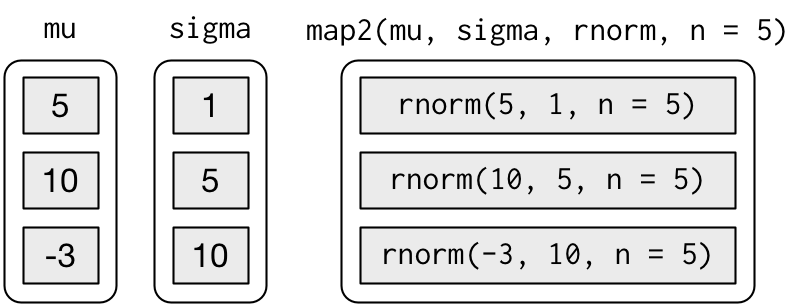

```r
mu    <-  c(5, 10 , -3)
sigma <-  c(1, 5  , 10)

map2(mu, sigma, rnorm, n = 5)
## [[1]]
## [1] 5.672220 5.555288 5.986476 5.363067 5.471528
##
## [[2]]
## [1]  5.395300  9.091701 11.024760  5.269679  6.194731
##
## [[3]]
## [1]   2.760504  10.792508  -6.771806 -11.236483  -2.378840
```

נשים לב שהארגומנטים שמשתנים בכל קריאה לפונקציה מגיעים לפני הפונקציה להפעלה. ארגומנטים שהם אותו הדבר לכל קריאה של הפונקציה מגיעים אח"כ.  
`map2` זו פשוט פונקציה שעוטפת `for loop`:

```r
map2 <- function(x, y, f, ...) {

  out <- vector("list", length(x))

  for (i in seq_along(x)) {

    out[[i]] <- f(x[[i]], y[[i]], ...)
  }

  out
}
```

`pmap` יעשה איטראציה על מספר גדול יותר של ארגומנטים. הוא מקבל רשימה של ארגומנטים:

```r
args1 <- list(n = c(1, 3, 5), mu,  sigma)
args1
```

```
## $n
## [1] 1 3 5
##
## [[2]]
## [1]  5 10 -3
##
## [[3]]
## [1]  1  5 10
```

```r
pmap(args1, rnorm)
## [[1]]
## [1] 3.584782
##
## [[2]]
## [1] 13.2099049 -0.9146218 10.6254068
##
## [[3]]
## [1]  -4.7510830  -8.3185818 -16.2798223  -4.8983515  -0.2970813
```

מוטב לתת שמות לארגומנטים שנכנסים לתוך `rnorm`. אחרת, הארגומנטים יותאמו לפי המיקום בו נרשמו.

```r
args1 <- list(n = c(1, 3, 5), mean = mu,  sd = sigma)

args1
```

```
## $n
## [1] 1 3 5
##
## $mean
## [1]  5 10 -3
##
## $sd
## [1]  1  5 10
```

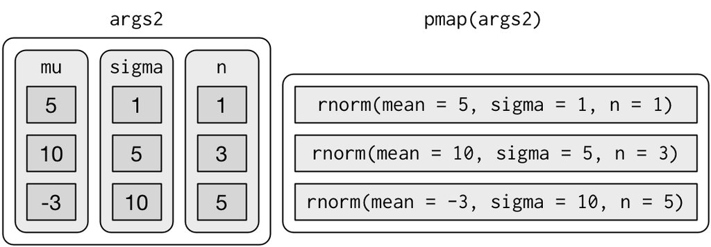

```r
pmap(args1, rnorm)
## [[1]]
## [1] 6.175979
##
## [[2]]
## [1] 19.258042 13.067800  5.983379
##
## [[3]]
## [1] -13.362647   5.213108  10.431797  -9.064689   8.749943
```

דוגמא: בטבלת ה- diamonds, ניצור גרפים המציגים את המחיר כפונקציה של ה-depth של היהלום עבור כל שילוב הקטגוריות של cut ושל color:

```r
(cut_color <- diamonds %>% distinct(cut, color))
```

```
## # A tibble: 35 x 2
##    cut       color
##    <ord>     <ord>
##  1 Ideal     E
##  2 Premium   E
##  3 Good      E
##  4 Premium   I
##  5 Good      J
##  6 Very Good J
##  7 Very Good I
##  8 Very Good H
##  9 Fair      E
## 10 Ideal     J
## # ... with 25 more rows
```

כעת נמשוך עמודות החוצה

```r
cut <- cut_color %>% pull(cut) %>% as.character()
color <- cut_color %>% pull(color) %>% as.character()
```

אם רוצים להשתמש בקיצור ה tilde-dot אז הארגומנטים יהיו `.x` לאובייקט הראשון ו- `.y` לאובייקט השני.

תחילה, כדאי להבין כיצד הקוד יפעל באיטראציה הראשונה

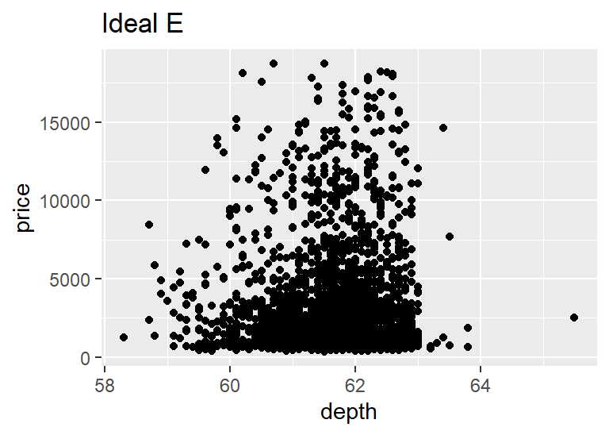

```r
.x <- cut[1]
.y <- color[1]

# make a scatterplot of price vs depth
diamonds %>%
  filter(cut == .x,
         color == .y) %>%
  ggplot() +
  geom_point(aes(x = depth, y = price)) +
  labs(title = glue::glue(.x, " ", .y))
```

נראה שזה עובד. נעתיק את הקוד ונזין אותו לתוך `map2`.

```r
plot_list <- map2(.x = cut,
                  .y = color,
                  .f = ~{
                    diamonds %>%
                      filter(cut == .x,
                             color == .y) %>%
                      ggplot() +
                      geom_point(aes(x = depth, y = price)) +
                      labs(title = glue::glue(.x, " ", .y))
                  })
```

אפשר לבחון חלק מתוצאות הרשימה

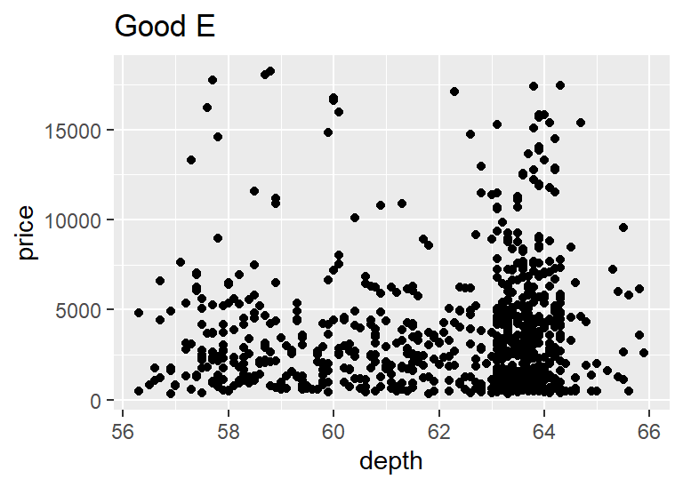

```r
plot_list[[3]]
```

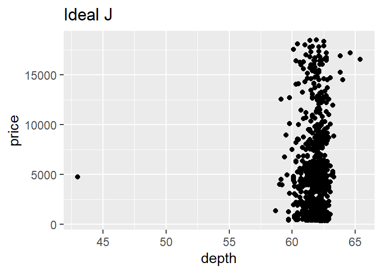

```r
plot_list[[10]]
```

# 8 other patterns

## 8.1 walk

Most functions are called for the value that they return, so it makes sense to capture and store the value with a `map()` function. But some functions are called primarily for their side-effects (e.g. `cat()`, `write.csv()`, or `ggsave()`) and it doesn’t make sense to capture their results.  
`walk()` Walk is an alternative to map that you use when you want to call a function for its side effects.

```r
welcome <- function(x) {
  cat("Welcome ", x, "!\n", sep = "")
}
names <- c("Eviatar", "Roman")

welcome(names[1])
## Welcome Eviatar!
welcome(names[2])
## Welcome Roman!

map(names, welcome)
## Welcome Eviatar!
## Welcome Roman!
## [[1]]
## NULL
##
## [[2]]
## NULL
```

the `walk` ignores the return values of the `.f` and instead return `.x` invisibly.

```r
walk(names, welcome)
## Welcome Eviatar!
## Welcome Roman!
```

A very common side-effect is saving something to disk, and when saving something to disk you always have a pair of values: the object and the path that you want to save it to.

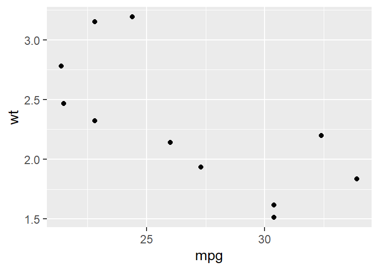

```r
plots <- mtcars %>%
  split(.$cyl) %>%
  map(~ggplot(., aes(mpg, wt)) + geom_point())

plots[[1]]
```

```r
paths <- stringr::str_c("8_plots/",names(plots), ".png")
paths
```

```
## [1] "8_plots/4.png" "8_plots/6.png" "8_plots/8.png"
```

```r
walk2(paths, plots, ggsave)
## Saving 4 x 2.85 in image
## Saving 4 x 2.85 in image
## Saving 4 x 2.85 in image

# or if you have more than 2 arguments:
pwalk(list(paths, plots), ggsave)
## Saving 4 x 2.85 in image
## Saving 4 x 2.85 in image
## Saving 4 x 2.85 in image
```

Another example:

```r
dir.create("8_test_data") # create a directory
```

```r
cyls <- split(mtcars, mtcars$cyl) # split the data into list of 3 datasets.

map(cyls, head, 2)
```

```
## $`4`
##             mpg cyl  disp hp drat   wt  qsec vs am gear carb
## Datsun 710 22.8   4 108.0 93 3.85 2.32 18.61  1  1    4    1
## Merc 240D  24.4   4 146.7 62 3.69 3.19 20.00  1  0    4    2
##
## $`6`
##               mpg cyl disp  hp drat    wt  qsec vs am gear carb
## Mazda RX4      21   6  160 110  3.9 2.620 16.46  0  1    4    4
## Mazda RX4 Wag  21   6  160 110  3.9 2.875 17.02  0  1    4    4
##
## $`8`
##                    mpg cyl disp  hp drat   wt  qsec vs am gear carb
## Hornet Sportabout 18.7   8  360 175 3.15 3.44 17.02  0  0    3    2
## Duster 360        14.3   8  360 245 3.21 3.57 15.84  0  0    3    4
```

```r
# create a vector of file names
(paths <- file.path("8_test_data", paste0("cyl-", names(cyls), ".csv")))
```

```
## [1] "8_test_data/cyl-4.csv" "8_test_data/cyl-6.csv" "8_test_data/cyl-8.csv"
```

```r
# write it into disk:
walk2(cyls, paths, write.csv)


list.files("8_test_data")
```

```
## [1] "cyl-4.csv" "cyl-6.csv" "cyl-8.csv"
```

## 8.2 reduce

`reduce()` is an operation that combines the elements of a vector into a single value. reducing f over 1:3 computes the value $f(f(1, 2), 3)$.

```r
reduce(c(1, 2, 3), `*`)
```

```
## [1] 6
```

```r
reduce(c(1, 2, 3), paste)
```

```
## [1] "1 2 3"
```

```r
(age <-  tibble(name = "John", age = 30))
```

```
## # A tibble: 1 x 2
##   name    age
##   <chr> <dbl>
## 1 John     30
```

```r
(sex <-  tibble(name = c("John", "Mary"), sex = c("M", "F")))
```

```
## # A tibble: 2 x 2
##   name  sex
##   <chr> <chr>
## 1 John  M
## 2 Mary  F
```

```r
(trt <- tibble(name = "Mary", treatment = "A"))
```

```
## # A tibble: 1 x 2
##   name  treatment
##   <chr> <chr>
## 1 Mary  A
```

```r
reduce(list(age, sex, trt), full_join)
## Joining, by = "name"
## Joining, by = "name"
## # A tibble: 2 x 4
##   name    age sex   treatment
##   <chr> <dbl> <chr> <chr>
## 1 John     30 M     <NA>
## 2 Mary     NA F     A
```

```r
vs <- list(
  c(1, 3, 5, 6, 10),
  c(1, 2, 3, 7, 8, 10),
  c(1, 2, 3, 4, 8, 9, 10)
)

vs %>% reduce(intersect)
```

```
## [1]  1  3 10
```

`reduce()` takes a “binary” function (i.e. a function with two primary inputs), and applies it repeatedly to a list until there is only a single element left.

`accumulate()` is similar but it keeps all the interim results. You could use it to implement a cumulative sum:

```r
x <- sample(10)
x
```

```
##  [1]  2 10  7  4  8  6  9  3  1  5
```

```r
x %>% accumulate(`+`)
```

```
##  [1]  2 12 19 23 31 37 46 49 50 55
```

## 8.3 modify

`modify()` always returns the same type of output as the input:

```r
df <- data.frame(
  x = 1:3,
  y = 6:4
)


modify(df, ~ .x * 2)
```

```
##   x  y
## 1 2 12
## 2 4 10
## 3 6  8
```

in this spectial case `map_df` and its variants works as-well: `map_dfr()` and `map_dfc()` return a data frame created by row-binding and column-binding respectively. They require dplyr to be installed.

```r
map_dfc(df, ~ .x * 2)
```

```
## # A tibble: 3 x 2
##       x     y
##   <dbl> <dbl>
## 1     2    12
## 2     4    10
## 3     6     8
```

```r
map_dfr(df, ~ .x * 2)
```

```
## # A tibble: 3 x 2
##       x     y
##   <dbl> <dbl>
## 1     2    12
## 2     4    10
## 3     6     8
```

**notes to explain:**  
“http://www.rebeccabarter.com/blog/2019-08-19_purrr/”

```r
map_df(df, ~ .x * 2)
```

```
## # A tibble: 3 x 2
##       x     y
##   <dbl> <dbl>
## 1     2    12
## 2     4    10
## 3     6     8
```

```r
map_df(df, ~ data_frame(x = .x), .id = "dist")
```

[output not shown]

## 8.4 modify_if

`modify` also has a pretty useful sibling, `modify_if()`, that only applies the function to elements that satisfy a specific criteria (specified by a “predicate function”, the second argument called `.p`). For instance, the following example only modifies the third entry since it is greater than 5.

```r
modify_if(.x = list(1, 4, 7),
          .p = function(x) x > 5,
          .f = add10)
## [[1]]
## [1] 1
##
## [[2]]
## [1] 4
##
## [[3]]
## [1] 17
```

## 8.5 iterate over values and indices

`imap()` allows you to iterate over the values and the indices of a vector in parallel.

`imap()` is like `map2()` in the sense that your `.f` gets called with two arguments, but here both are derived from the vector. `imap(x, f)` is equivalent to `map2(x, names(x), f)` if x has names, and `map2(x, seq_along(x), f)` if it does not.

`imap()` is often useful for constructing labels:

```r
imap_chr(iris, ~ paste0("The first value of ", .y, " is ", .x[[1]]))
```

```
##                             Sepal.Length
## "The first value of Sepal.Length is 5.1"
##                              Sepal.Width
##  "The first value of Sepal.Width is 3.5"
##                             Petal.Length
## "The first value of Petal.Length is 1.4"
##                              Petal.Width
##  "The first value of Petal.Width is 0.2"
##                                  Species
##   "The first value of Species is setosa"
```

If the vector is unnamed, the second argument will be the index:

```r
x <- map(1:6, ~ sample(1000, 5))
x
## [[1]]
## [1] 342 157 717 375 487
##
## [[2]]
## [1] 568 558  11 191 846
##
## [[3]]
## [1] 381 771 886 766 712
##
## [[4]]
## [1] 548 335 138 260  22
##
## [[5]]
## [1]  59  73 249 432 278
##
## [[6]]
## [1] 756 725 611 705 594
imap_chr(x, ~ paste0("The highest value of ", .y, " is ", max(.x)))
```

```
## [1] "The highest value of 1 is 717" "The highest value of 2 is 846"
## [3] "The highest value of 3 is 886" "The highest value of 4 is 548"
## [5] "The highest value of 5 is 432" "The highest value of 6 is 756"
```

## 8.6 more examples

`keep()` and `discard()` keep elements of the input where the predicate is `TRUE` or `FALSE` respectively:

```r
iris %>% keep(is.factor) %>% head()
```

```
##   Species
## 1  setosa
## 2  setosa
## 3  setosa
## 4  setosa
## 5  setosa
## 6  setosa
```

```r
iris %>% discard(is.factor) %>% head()
```

```
##   Sepal.Length Sepal.Width Petal.Length Petal.Width
## 1          5.1         3.5          1.4         0.2
## 2          4.9         3.0          1.4         0.2
## 3          4.7         3.2          1.3         0.2
## 4          4.6         3.1          1.5         0.2
## 5          5.0         3.6          1.4         0.2
## 6          5.4         3.9          1.7         0.4
```

`some()` and `every()` determine if the predicate is true for any or for all of the elements.

```r
x <- list(1:5, letters, list(10))

x %>% some(is_character)
```

```
## [1] TRUE
```

```r
x %>% every(is_vector)
```

```
## [1] TRUE
```

`detect()` finds the first element where the predicate is true; `detect_index()` returns its position.

```r
(x <- sample(10))
```

```
##  [1]  5  7  1  8  6 10  2  4  3  9
```

```r
x %>% detect(~ . > 5)
```

```
## [1] 7
```

```r
x %>% detect_index(~ . > 5)
```

```
## [1] 2
```

`head_while()` and `tail_while()` take elements from the start or end of a vector while a predicate is true:

```r
x %>% head_while(~ . > 5)
## integer(0)

x %>% tail_while(~ . > 5)
```

```
## [1] 9
```

## 8.7 excercises

1. Create an enhanced `col_summary()` that applies a summary function to every numeric column in a data frame.
2. A possible base R equivalent of `col_summary()` is:

```r
col_sum3 <- function(df, f) {
  is_num <- sapply(df, is.numeric)
  df_num <- df[, is_num]

  sapply(df_num, f)
}
```

But it has a number of bugs as illustrated with the following inputs:

```r
df <- tibble(
  x = 1:3,
  y = 3:1,
  z = c("a", "b", "c")
)
# OK
col_sum3(df, mean)
## x y
## 2 2

# Has problems: don't always return numeric vector
col_sum3(df[1:2], mean)
## x y
## 2 2

col_sum3(df[1], mean)
## x
## 2

col_sum3(df[0], mean)
```

```
## Error: Must subset columns with a valid subscript vector.
## x Subscript `is_num` has the wrong type `list`.
## i It must be logical, numeric, or character.
```

What causes the bugs?